# Tidy Tuesday – National Park Species

10/8/24

Author

Katelyn McClure

```r
# load necessary packages
library(tidyverse)
```

```r
# read in the data
nps_species <- readr::read_csv('https://raw.githubusercontent.com/rfordatascience/tidytuesday/master/data/2024/2024-10-08/most_visited_nps_species_data.csv', show_col_types = FALSE)
```

```r
# exploring data
nps_species %>%
  group_by(TEStatus) %>%
  summarize(n())
```

```
# A tibble: 19 × 2
   TEStatus `n()`
   <chr>    <int>
 1 50         488
 2 C            8
 3 D3A          1
 4 DM          30
 5 DNS          1
 6 E           49
 7 E,EXPN       1
 8 EXPN         6
 9 PE           5
10 PSAT         1
11 PT           2
12 RT         541
13 RT,SC        3
14 SC        2293
15 SC,SU        1
16 SU         244
17 T           49
18 UR          46
19 <NA>     57350
```

```r
# What is "50"?? Is it unique to a specific park?
nps_species %>%
  filter(TEStatus == "50") %>%
  group_by(ParkCode) %>%
  summarize(count = n())
```

```
# A tibble: 15 × 2
   ParkCode count
   <chr>    <int>
 1 ACAD        26
 2 BRCA         8
 3 CUVA        73
 4 GLAC        26
 5 GRCA        36
 6 GRSM        73
 7 GRTE        19
 8 HOSP        71
 9 INDU        65
10 JOTR         8
11 OLYM        22
12 ROMO        16
13 YELL        23
14 YOSE        10
15 ZION        12
```

```r
# Nope </3 It's in all of them
```

Due to the size of the dataset, I also decided to combine some of the similar Status Codes into a broader category according to the Endangered Species Act Status Codes in ECOS to simplify the number of factors and to make the categories more recognizable. For example, I combined “PT” (Proposed Threatened) with “T” (Threatened) into a broader “Threatened” category.

```r
# Create easier to understand categories for TEStatus
nps_species_TEStatus <- nps_species %>%
  mutate(TEStatus2 = ifelse(is.na(TEStatus), "Not of Concern", TEStatus)) %>% # replace NA with "Not of Concern"
  mutate(TEStatus3 = case_when(
    TEStatus2 %in% c("D3A", "E", "E,EXPN", "PE") ~ "Endangered",
    TEStatus2 %in% c("EXPN", "PSAT", "PT", "T") ~ "Threatened",
    TEStatus2 == "Not of Concern" ~ "Not of Concern",
    TEStatus2 %in% c("C", "RT,SC", "SC", "SC,SU", "UR") ~ "Species of Minimal Concern",
    TEStatus2 == "DM" ~ "In Recovery",
    TEStatus2 %in% c("50", "DNS", "SU", "RT") ~ "Other",
  )) %>%
  mutate(TEStatus3 = as.factor(TEStatus3)) %>%
  mutate(TEStatus3 = fct_relevel(TEStatus3, "Endangered", "Threatened", "Species of Minimal Concern", "In Recovery", "Not of Concern", "Other"))

nps_species_TEStatus %>%
  group_by(TEStatus3) %>%
  summarize(count = n())
```

```
# A tibble: 6 × 2
  TEStatus3                  count
  <fct>                      <int>
1 Endangered                    56
2 Threatened                    58
3 Species of Minimal Concern  2351
4 In Recovery                   30
5 Not of Concern             57350
6 Other                       1274
```

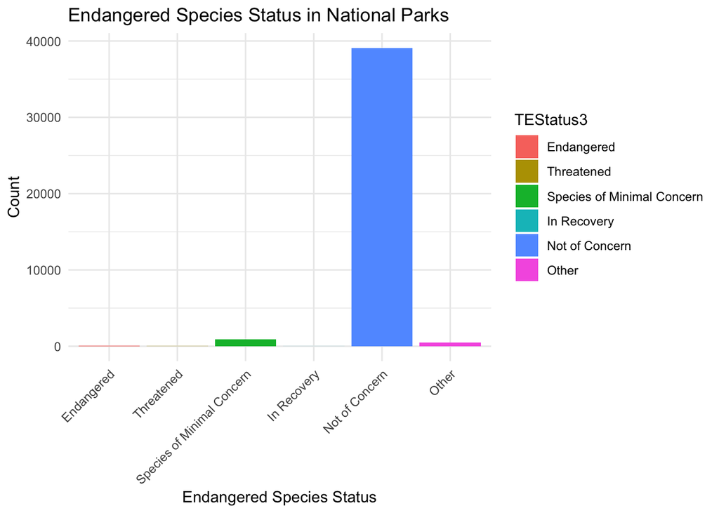

```r
# plot
# maybe a bar chart bar plot showing the types of CategoryNames and how endangered they are? or could split it up by park? Could show proportions since I'm assuming some parks probably have more species in them?

ggplot(nps_species_TEStatus %>% filter(ParkCode == "GRSM" | ParkCode =="GRCA" |ParkCode == "ZION" | ParkCode =="YELL" | ParkCode =="ROMO"), aes(x = TEStatus3, fill = TEStatus3)) +
  geom_bar() +
  labs(title = "Endangered Species Status in National Parks",
       x = "Endangered Species Status",
       y = "Count") +
  theme_minimal() +
  theme(axis.text.x = element_text(angle = 45, hjust = 1))
```

The below plot shows the proportion of species in the Great Smoky Mountains National Park (`ParkCode == GRSM`) broken down by `CategoryName`. I chose the Great Smoky Mountains because it was the most visited national park in 2023. The plot shows that the majority of species in the park are “Species of Minimal Concern” and “Not of Concern.” Animals, such as Mammals, Fish, and Birds have higher proportions of “Threatened” and “Endangered” species. Around half of the fish are `TEStatus == "50"`, which is the mysterious category I could not find any information about. The “50” category is not exclusively fish. I also added the total number of species in the park above the bars to give context to the proportions. Yes, I hacked it together by fiddling with the fill labs(), but it works when the graph is just the right size (which it isn’t in the html output) BUT it’s close enough and I spent so long trying to figure out how to get the numbers there in general so that was enough of a win for me.

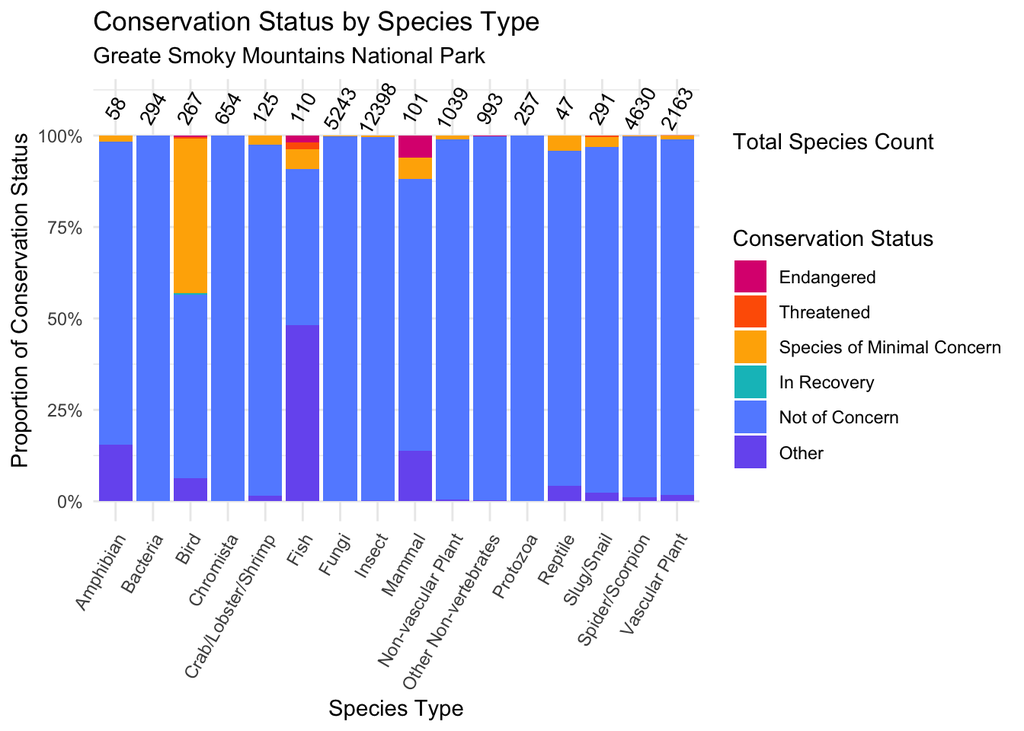

```r
# Total species in GRSM for the text above the bars
total_species <- nps_species_TEStatus %>%
  filter(ParkCode == "GRSM") %>%
  group_by(CategoryName) %>%
  summarise(total_species = n())

# Plot
nps_species_TEStatus %>%
  filter(ParkCode == "GRSM") %>% # only Smoky Mtns
  group_by(CategoryName, TEStatus3) %>%
  summarise(count = n()) %>%
  mutate(prop = count / sum(count)) %>% # calculate proportions
  ggplot(aes(x = CategoryName, y = prop, fill = TEStatus3)) +
  geom_bar(stat = "identity", position = "fill") + # creates the bar plot, Copilot helped me with this
  geom_text(data = total_species, aes(x = CategoryName, y = 1.075, label = total_species),
            inherit.aes = FALSE, size = 3.5, angle = 60) + # adds numbers above bars, thanks ChatGPT for the inherit.aes help <3
  scale_y_continuous(labels = scales::percent_format(), limits = c(0, 1.10), breaks = c(0, 0.25, 0.5, 0.75, 1)) + # format y-axis labels, thanks ChatGPT for the percent_format help <3
  labs(
    x = "Species Type",
    y = "Proportion of Conservation Status",
    title = "Conservation Status by Species Type",
    fill = "Total Species Count\n\n\n\nConservation Status",
    subtitle = "Greate Smoky Mountains National Park"
  ) +
  theme_minimal() +
  scale_fill_manual(values = c("Endangered" = "#DC267F", "Threatened" = "#FE6100", "Species of Minimal Concern" = "#FFB000", "In Recovery" = "#00BFC4", "Not of Concern" = "#648FFF", "Other" = "#785EF0")) + # sets color palette
  theme(axis.text.x = element_text(angle = 60, hjust = 1))  # tilts the x-axis labels so they're easier to read
```

```r
# Is "50" unique to fish?
nps_species_TEStatus %>%
  filter(TEStatus == "50") %>%
  group_by(CategoryName) %>%
  summarize(count = n())
```

```
# A tibble: 10 × 2
   CategoryName          count
   <chr>                 <int>
 1 Amphibian                20
 2 Bird                     58
 3 Crab/Lobster/Shrimp       1
 4 Fish                    289
 5 Insect                    4
 6 Mammal                   61
 7 Other Non-vertebrates    14
 8 Reptile                   6
 9 Slug/Snail                3
10 Vascular Plant           32
```

```r
# No </3
```